# WeRateDogs analysis and insights

## After cleaning the data set I made some visualizations functions in order to make more information about the data

## Pie chart for doggy meter

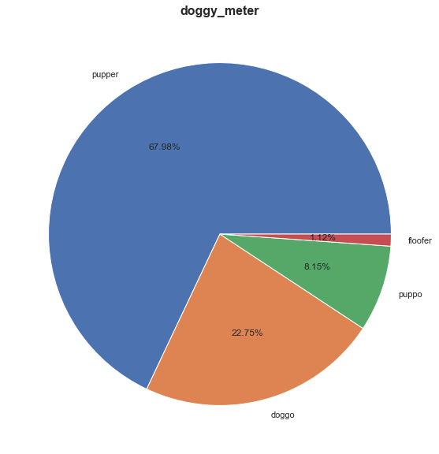

```python
#showing a Pie chart for the doggy meter
tweets['doggy_meter'].value_counts().plot(kind='pie', autopct='%.2f%%', figsize=(10,10))

plt.ylabel('')
plt.title('doggy_meter', weight='bold', fontsize=16);
```

#### Its not a strange result as the pupper is the medium dogs witch in tern would be the most common dogs

## Top 10 predictions

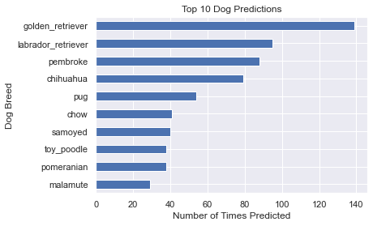

```python
#Make a bar plot for top 10 dog breeds
tweets['p1'].value_counts()[9::-1].plot(kind='barh')
plt.title('Top 10 Dog Predictions')
plt.xlabel('Number of Times Predicted')
plt.ylabel('Dog Breed')
plt.fontsize = 12
```

## Source effects

```
Twitter for iPhone     1985
Vine - Make a Scene    91
Twitter Web Client     30
TweetDeck              11
Name: source, dtype: int64
```

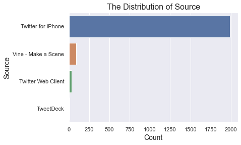

```python
sorted_source = tweets['source'].value_counts().index
print(tweets['source'].value_counts())
sns.set(style="darkgrid")
sns.countplot(data = tweets, y = 'source', order = sorted_source)
plt.xticks(rotation = 360)
plt.xlabel('Count', fontsize=14)
plt.ylabel('Source', fontsize=14)
plt.title('The Distribution of Source',fontsize=16)
```

#### Twitter for Iphone is the most number of sources, that may give you the sense that apple users are more interested in dogs, that may be translated to someways of richness, the very least source is tweetdeck

## Retweets vs favourites

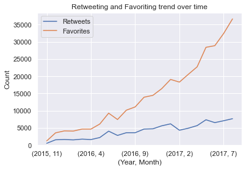

```python
plt.subplots(1, sharex=True)
tweets.retweet_count.groupby([tweets["timestamp"].dt.year, tweets["timestamp"].dt.month]).mean().plot(kind='line')
tweets.favorite_count.groupby([tweets["timestamp"].dt.year, tweets["timestamp"].dt.month]).mean().plot(kind='line').set_ylim(0, )
plt.title('Retweeting and Favoriting trend over time')
plt.ylabel('Count')
plt.xlabel('(Year, Month)')
plt.legend(('Retweets', 'Favorites'))
plt.savefig('ret_fav')
```

#### by the time and noticing the relation between retweets and favourites, you will find that favourites is increasingly dramatically more than retweets, and the gap is contiously incresing, in 2016 for example the gap was about 3000 but iin 2017 the gap was about 30000, that may have a lot of meaning like decreasing in the social sense, or may be an increasing usage of favourite as a way to save tweets to return for sometime later

## Tweets decreasing over the time

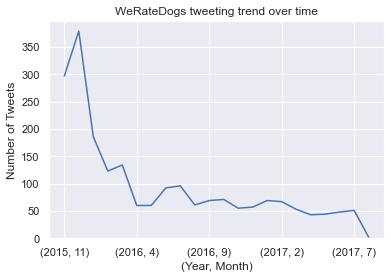

```python
data = tweets.tweet_id.groupby([tweets["timestamp"].dt.year, tweets["timestamp"].dt.month]).count()
ax = data.plot(kind='line', title='WeRateDogs tweeting trend over time')
ax.set_xlabel("(Year, Month)")
ax.set_ylabel("Number of Tweets")
ax.set_ylim(0, )
plt.savefig('tweet_trend')
```